# CS 1675 Spring 2020

Applied machine learning - Regression Demo

Dr. Joseph P. Yurko

1/29/2020

## Overview

Let’s perform model building, resampling, and evaluation steps for a real data example. We will also introduce more advanced methods, many of which you will work with directly in this course.

We will continue use packages and functions from the `tidyverse`, but we will also introduce the `caret` package which manages the training, resampling, and evaluation steps for us. Once you have `caret` downloaded and installed, `caret` will prompt you when you need to download and install other packages specific to the model types we will use in this demo. We will also use the `corrplot` package for some visualizations.

```r
library(dplyr)
```

```r
library(ggplot2)
library(caret)
```

## Data

The data comes from the UCI machine learning repository. We will work through a regression problem, specifically one interested in predicted the compressive strength of concrete based on multiple factors. Please see the following [link](https://archive.ics.uci.edu/ml/datasets/Concrete+Compressive+Strength) which discusses the variables in more detail, as well as the citations about the data.

The code chunk below downloads the Excel file which stores the data and reads it into `R`. For simplicity, the data set is downloaded into our current working directory.

```r
uci_url <- "https://archive.ics.uci.edu/ml/machine-learning-databases/concrete/compressive/Concrete_Data.xls"

download.file(uci_url, destfile = "concrete_data.xls", mode = "wb")

concrete <- readxl::read_xls("concrete_data.xls", col_names = TRUE)
```

Let’s first just look at the names of the variables.

```r
concrete %>% names()
```

```
## [1] "Cement (component 1)(kg in a m^3 mixture)"
## [2] "Blast Furnace Slag (component 2)(kg in a m^3 mixture)"
## [3] "Fly Ash (component 3)(kg in a m^3 mixture)"
## [4] "Water  (component 4)(kg in a m^3 mixture)"
## [5] "Superplasticizer (component 5)(kg in a m^3 mixture)"
## [6] "Coarse Aggregate  (component 6)(kg in a m^3 mixture)"
## [7] "Fine Aggregate (component 7)(kg in a m^3 mixture)"
## [8] "Age (day)"
## [9] "Concrete compressive strength(MPa, megapascals)"
```

Those are some really long variable names…let’s change them. The renamed data set is assigned to the `my_concrete` object below.

```r
my_concrete <- concrete %>%
  purrr::set_names(c("cement", "slag", "flyash", "water", "superplast", "coarseagg",
                     "fineagg", "age", "strength"))
```

Now, let’s explore the data set. Start by simply looking at the data types and a glimpse of the first few rows.

```r
my_concrete %>% glimpse()
```

```
## Observations: 1,030
## Variables: 9
## $ cement     <dbl> 540.0, 540.0, 332.5, 332.5, 198.6, 266.0, 380.0, 38...
## $ slag       <dbl> 0.0, 0.0, 142.5, 142.5, 132.4, 114.0, 95.0, 95.0, 1...
## $ flyash     <dbl> 0, 0, 0, 0, 0, 0, 0, 0, 0, 0, 0, 0, 0, 0, 0, 0, 0, ...
## $ water      <dbl> 162, 162, 228, 228, 192, 228, 228, 228, 228, 228, 1...
## $ superplast <dbl> 2.5, 2.5, 0.0, 0.0, 0.0, 0.0, 0.0, 0.0, 0.0, 0.0, 0...
## $ coarseagg  <dbl> 1040.0, 1055.0, 932.0, 932.0, 978.4, 932.0, 932.0, ...
## $ fineagg    <dbl> 676.0, 676.0, 594.0, 594.0, 825.5, 670.0, 594.0, 59...
## $ age        <dbl> 28, 28, 270, 365, 360, 90, 365, 28, 28, 28, 90, 28,...
## $ strength   <dbl> 79.986111, 61.887366, 40.269535, 41.052780, 44.2960...
```

Next, let’s summarize each of the variables.

```r
my_concrete %>% summary()
```

```
##      cement           slag           flyash           water
##  Min.   :102.0   Min.   :  0.0   Min.   :  0.00   Min.   :121.8
##  1st Qu.:192.4   1st Qu.:  0.0   1st Qu.:  0.00   1st Qu.:164.9
##  Median :272.9   Median : 22.0   Median :  0.00   Median :185.0
##  Mean   :281.2   Mean   : 73.9   Mean   : 54.19   Mean   :181.6
##  3rd Qu.:350.0   3rd Qu.:142.9   3rd Qu.:118.27   3rd Qu.:192.0
##  Max.   :540.0   Max.   :359.4   Max.   :200.10   Max.   :247.0
##    superplast       coarseagg         fineagg           age
##  Min.   : 0.000   Min.   : 801.0   Min.   :594.0   Min.   :  1.00
##  1st Qu.: 0.000   1st Qu.: 932.0   1st Qu.:731.0   1st Qu.:  7.00
##  Median : 6.350   Median : 968.0   Median :779.5   Median : 28.00
##  Mean   : 6.203   Mean   : 972.9   Mean   :773.6   Mean   : 45.66
##  3rd Qu.:10.160   3rd Qu.:1029.4   3rd Qu.:824.0   3rd Qu.: 56.00
##  Max.   :32.200   Max.   :1145.0   Max.   :992.6   Max.   :365.00
##     strength
##  Min.   : 2.332
##  1st Qu.:23.707
##  Median :34.443
##  Mean   :35.818
##  3rd Qu.:46.136
##  Max.   :82.599
```

Let’s take a look at the histograms of the variables.

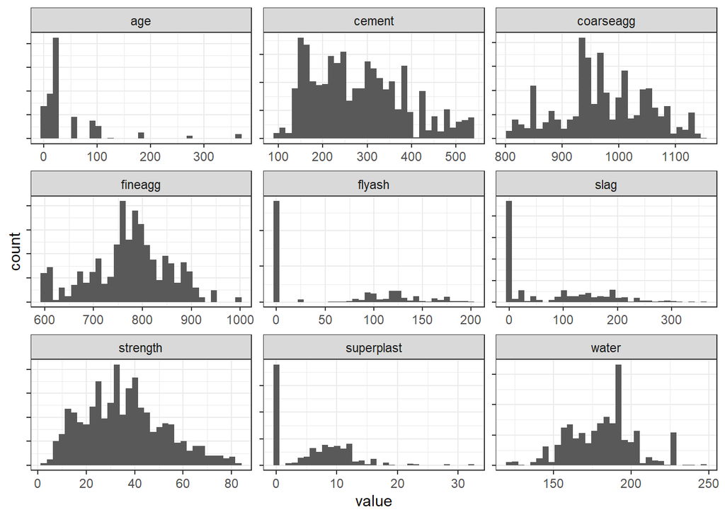

```r
my_concrete %>%
  tibble::rowid_to_column("obs_id") %>%
  tidyr::gather(key = "key", value = "value", -obs_id) %>%
  ggplot(mapping = aes(x = value)) +
  geom_histogram(bins = 33) +
  facet_wrap(~key, scales = "free") +
  theme_bw() +
  theme(axis.text.y = element_blank())
```

The response or output variable is `strength`. Let’s now look at scatter plots between the response and each of the 8 input variables. Can we see any trends?

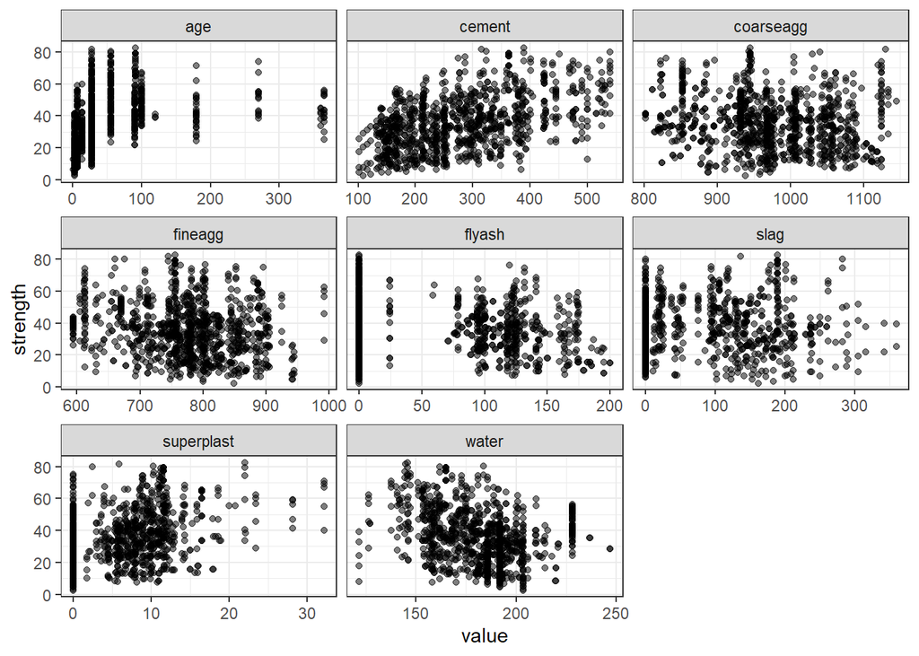

```r
my_concrete %>%
  tibble::rowid_to_column("obs_id") %>%
  tidyr::gather(key = "key", value = "value", -obs_id, -strength) %>%
  ggplot(mapping = aes(x = value, y = strength)) +
  geom_point(alpha = 0.5) +
  facet_wrap(~key, scales = "free_x") +
  theme_bw()
```

Let’s now study the input variables in more detail. How many unique values are there for each input?

```r
my_concrete %>%
  tibble::rowid_to_column("obs_id") %>%
  tidyr::gather(key = "key", value = "value", -obs_id, -strength) %>%
  group_by(key) %>%
  summarise(num_rows = n(),
            num_missing = sum(is.na(value)),
            num_unique = n_distinct(value)) %>%
  knitr::kable()
```

| key | num_rows | num_missing | num_unique |
| --- | --- | --- | --- |
| age | 1030 | 0 | 14 |
| cement | 1030 | 0 | 280 |
| coarseagg | 1030 | 0 | 284 |
| fineagg | 1030 | 0 | 304 |
| flyash | 1030 | 0 | 163 |
| slag | 1030 | 0 | 187 |
| superplast | 1030 | 0 | 155 |
| water | 1030 | 0 | 205 |

Are the inputs correlated with each other?

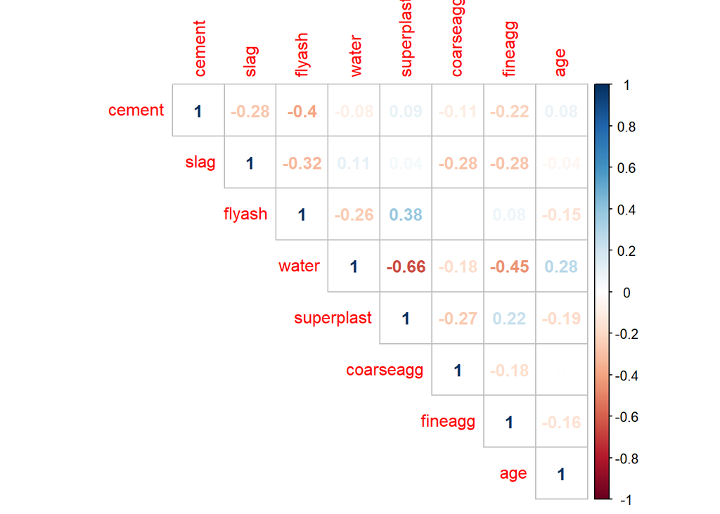

```r
my_concrete %>%
  select(-strength) %>%
  as.data.frame() %>%
  cor() %>%
  corrplot::corrplot(method = "number", type = "upper")
```

We can rearrage the variables in the correlation plot to group those that are highly correlated together. For this example, the grouping does not reveal too much more than what we already saw. However, such an operation can be useful when there are dozens of input variables. An unsupervised learning technique is used to *cluster* the variables together. We will discuss how such a cluster algorithm later in the semester.

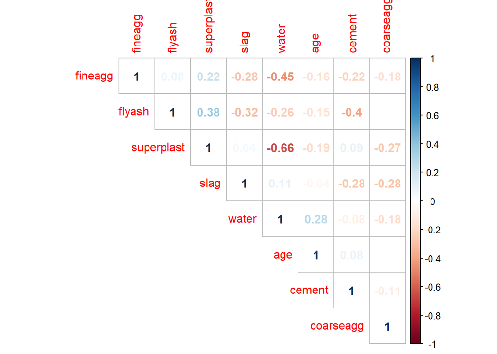

```r
my_concrete %>%
  select(-strength) %>%
  as.data.frame() %>%
  cor() %>%
  corrplot::corrplot(method = "number", type = "upper",
                     order = "hclust")
```

## Resampling scheme

We will us k-fold cross-validation to assess overfitting and/or underfitting of the various models we will build. As discussed in lecture, this will help identify if a model is too complex and is thus only explaining the noise in the training data set. K-fold cross-validation is a resampling technique that breaks up the data set into multiple training and test splits. In this demonstration, we will use the `caret` package to manage the resampling scheme, model training, predictions, and calculation of the performance metrics.

Specifically, we will use 5-fold cross-validation repeated 3 times. In `caret`, the resampling scheme is specified by the `trainControl()` function where we specify the `method`, the `number` of folds, and if we will `repeat` the process. In addition to the resampling scheme we must also tell `caret` what our primary performance metric is. Multiple performance metrics can still be studied, but we will specify the primary metric as the RMSE. The code chunk below defines the variables `my_ctrl` and `my_metric` which store the resampling control information and the metric type, respectively.

```r
my_ctrl <- trainControl(method = "repeatedcv", number = 5, repeats = 3)

my_metric <- "RMSE"
```

## Model training

We will try out multiple candidate models, ranging from simple to complex. We will start out with linear methods, before trying out non-linear models. The models are trained in `caret` with the `train()` function. After specifying the inputs and outputs, and the data, we must tell `caret` the type of model or the `method` to use. There are hundreds of models available for training through `caret`. We will show a handful of those in this demonstration.

The `train()` function allows us to specify if pre-processing steps are to be applied to the inputs via the `preProc` argument. `caret` has a variety of pre-processing actions it can perform, and the nice aspect of including them within the `train()` directly is that the pre-processing actions are performed on a per-fold basis. Thus, if we center the inputs by subtracting out the mean, the centering is based on the sample average within each fold.

The following code chunks show how to specify other arguments to `train()`. We will discuss those arguments throughout the semester.

When we train each model we **must** specify the random seet with the `set.seed()` function before each `train()` call. This forces the random data splits within the folds to be same across the models. If we didn’t do this, we would not have an apples-to-apples comparison in the cross-validation performance metrics since the hold-out sets would be different between models.

### Linear models

Let’s start out with a simple linear model, assuming linear additive terms for all 8 inputs. We can specify the model formulation through the formula interface. Rather than writing out each input to create out simple model, we can use the `R` short cut `.` to represent “everything else”. Thus, to tell `caret` to fit a model for `strength` as a function of inputs we can write `strength ~ .`. Note that to use the “everything else” syntax for the inputs, the data set we specify as the `data` argument to `train()`, must ONLY contain the inputs and the response. It **cannot** include other variables, such as observation indices or other variables.

Since the inputs span different ranges, we will standardize the inputs so that all are mean zero and variance one. Thus, our linear model will study the relative effect of each input on the response. To standardize we must instruct `caret` to first `"center"` and then `"scale"` the variables. The code chunk below shows the specific syntax for doing so.

```r
set.seed(20201)
fit_lm <- train(strength ~ ., data = my_concrete,
                method = "lm",
                metric = my_metric,
                preProc = c("center", "scale"),
                trControl = my_ctrl)
```

Printing the `fit_lm` result to screen displays useful information which summarizes how the cross-validation, pre-processing, and model training were performed. This way if we ever forget how we trained a model (for example if we saved it for use later on), we can just print the object to screen to tell us that kind of information. The object also tells how how the model performed on average across the hold-out sets.

```r
fit_lm
```

```
## Linear Regression
##
## 1030 samples
##    8 predictor
##
## Pre-processing: centered (8), scaled (8)
## Resampling: Cross-Validated (5 fold, repeated 3 times)
## Summary of sample sizes: 823, 825, 823, 824, 825, 825, ...
## Resampling results:
##
##   RMSE      Rsquared   MAE
##   10.48192  0.6115575  8.309649
##
## Tuning parameter 'intercept' was held constant at a value of TRUE
```

The simple linear additive regression model is a nice starting point, but obviously it’s limited. Let’s slowly start to increase the complexity by considering interaction terms. In `R` we can use a shortcut syntax to specify all pair-wise interactions with the formula interface `strength ~ (.)^2`. At first this seems like we wanted to square “everything else”. However, in `R` this is a shortcut statement for **all pair-wise interactions**. If we allow for all pair-wise interactions, the number of unknown coefficients or parameters in our model will increase. We can check just how many coefficients will exist in the model by checking the design matrix. It’s ok if you’re not sure what the next code chunk represents, we will cover design matrices in detailed in a few lectures. Just look how many parameters we now have to consider compared with the original number of parameters in our simple linear additive model.

```r
model.matrix(strength ~ (.)^2, data = my_concrete) %>% dim()
```

```
## [1] 1030   37
```

Because we have so many more terms when we include interactions, let’s use a penalized or **regularized** regression model. Regularization tries to prevent large parameter values from occuring. We will use the elastic net model which is a blending of lasso and ridge regression. The elastic net model is contained within the `glmnet` package and so when you train elastic net the first time with `caret`, you will be prompted to download the `glmnet` package. Please follow the onscreen prompts to do so.

The code chunk below trains the elastic net model with all pair-wise interactions, using syntax similar to that of the simple linear additive model. The important changes are though the change in the formula, and the change in the `method` argument to `"glmnet"`. After training is complete, the `caret` model object is printed to the screen. Notice how there are multiple rows of performance results. That is because elastic net model consists of two tuning parameters, `alpha` and `lambda`. We will talk about these parameters in more detail later in the semester. The important thing to know for now is that more complex models may have parameters that are difficult to learn or fit from the training data directly. Such tuning parameters are optimized via cross-validation.

```r
set.seed(20201)
fit_glmnet_pairs <- train(strength ~ (.)^2, data = my_concrete,
                          method = "glmnet",
                          metric = my_metric,
                          preProc = c("center", "scale"),
                          trControl = my_ctrl)

fit_glmnet_pairs
```

```
## glmnet
##
## 1030 samples
##    8 predictor
##
## Pre-processing: centered (36), scaled (36)
## Resampling: Cross-Validated (5 fold, repeated 3 times)
## Summary of sample sizes: 823, 825, 823, 824, 825, 825, ...
## Resampling results across tuning parameters:
##
##   alpha  lambda      RMSE       Rsquared   MAE
##   0.10   0.01743014   8.747674  0.7276597  6.878284
##   0.10   0.17430140   8.984880  0.7129040  7.035014
##   0.10   1.74301397   9.282839  0.6962878  7.297514
##   0.55   0.01743014   8.797374  0.7246851  6.903241
##   0.55   0.17430140   9.072566  0.7073587  7.104721
##   0.55   1.74301397   9.739289  0.6791011  7.783645
##   1.00   0.01743014   8.864583  0.7204882  6.938433
##   1.00   0.17430140   9.141432  0.7031976  7.157646
##   1.00   1.74301397  10.335965  0.6561730  8.309286
##
## RMSE was used to select the optimal model using the smallest value.
## The final values used for the model were alpha = 0.1 and lambda
##  = 0.01743014.
```

To check to make sure the `caret` model was in fact accounting for all pair-wise interactions, let’s access the fit model object directly and extract the coefficient or parameter names. Those names are printed to the screen below. In `R`, multiplication of two variables in formula names are represented by the `:` sign.

```r
coef(fit_glmnet_pairs$finalModel) %>% rownames()
```

```
##  [1] "(Intercept)"          "cement"               "slag"
##  [4] "flyash"               "water"                "superplast"
##  [7] "coarseagg"            "fineagg"              "age"
## [10] "cement:slag"          "cement:flyash"        "cement:water"
## [13] "cement:superplast"    "cement:coarseagg"     "cement:fineagg"
## [16] "cement:age"           "slag:flyash"          "slag:water"
## [19] "slag:superplast"      "slag:coarseagg"       "slag:fineagg"
## [22] "slag:age"             "flyash:water"         "flyash:superplast"
## [25] "flyash:coarseagg"     "flyash:fineagg"       "flyash:age"
## [28] "water:superplast"     "water:coarseagg"      "water:fineagg"
## [31] "water:age"            "superplast:coarseagg" "superplast:fineagg"
## [34] "superplast:age"       "coarseagg:fineagg"    "coarseagg:age"
## [37] "fineagg:age"
```

Since we tried a regularized model with all pair wise interactions, let’s also consider all three-way interactions. The short cut operator `strength ~ (.)^3` will create that model. The model is trained in the code chunk below, with the results printed to screen.

```r
set.seed(20201)
fit_glmnet_trips <- train(strength ~ (.)^3, data = my_concrete,
                          method = "glmnet",
                          metric = my_metric,
                          preProc = c("center", "scale"),
                          trControl = my_ctrl)

fit_glmnet_trips
```

```
## glmnet
##
## 1030 samples
##    8 predictor
##
## Pre-processing: centered (92), scaled (92)
## Resampling: Cross-Validated (5 fold, repeated 3 times)
## Summary of sample sizes: 823, 825, 823, 824, 825, 825, ...
## Resampling results across tuning parameters:
##
##   alpha  lambda      RMSE       Rsquared   MAE
##   0.10   0.01873665   8.667001  0.7341897  6.723477
##   0.10   0.18736653   8.684380  0.7314141  6.789224
##   0.10   1.87366527   9.003181  0.7130221  7.088895
##   0.55   0.01873665   8.702935  0.7318600  6.750079
##   0.55   0.18736653   8.797287  0.7242179  6.903332
##   0.55   1.87366527   9.424748  0.6998797  7.528972
##   1.00   0.01873665   8.742452  0.7294001  6.769642
##   1.00   0.18736653   8.895848  0.7183767  6.987264
##   1.00   1.87366527  10.167373  0.6684289  8.198472
##
## RMSE was used to select the optimal model using the smallest value.
## The final values used for the model were alpha = 0.1 and lambda
##  = 0.01873665.
```

As a check, print the names of the coefficients for the model with all three-way or triplet interactions.

```r
coef(fit_glmnet_trips$finalModel) %>% rownames()
```

```
##  [1] "(Intercept)"                  "cement"
##  [3] "slag"                         "flyash"
##  [5] "water"                        "superplast"
##  [7] "coarseagg"                    "fineagg"
##  [9] "age"                          "cement:slag"
## [11] "cement:flyash"                "cement:water"
## [13] "cement:superplast"            "cement:coarseagg"
## [15] "cement:fineagg"               "cement:age"
## [17] "slag:flyash"                  "slag:water"
## [19] "slag:superplast"              "slag:coarseagg"
## [21] "slag:fineagg"                 "slag:age"
## [23] "flyash:water"                 "flyash:superplast"
## [25] "flyash:coarseagg"             "flyash:fineagg"
## [27] "flyash:age"                   "water:superplast"
## [29] "water:coarseagg"              "water:fineagg"
```

[output cut: 32 more lines]

Let’s consider a linear model that is particularly well suited to deal with correlated inputs. Although we saw the inputs were not highly related to each other in this example, it’s still a useful model to know about. Partial Least Squares (PLS) finds a linear combination of the inputs, and fits those transformed variables to the response. We will apply the linear combinations to all pair-wise interactions rather than the inputs directly. As with elastic-net there is a tuning parameter to optimize for, the number of “latent component” `ncomp`. The code chunk below shows how to train a PLS model, as well as specify a custom grid search for the tuning parameter. Custom grid searches can provide more fine grain detail when optimizing the tuning parameters.

```r
pls_grid <- expand.grid(ncomp = seq(1, 25, by = 2))

set.seed(20201)
fit_pls <- train(strength ~ (.)^2, data = my_concrete,
                 method = "pls",
                 metric = my_metric,
                 tuneGrid = pls_grid,
                 preProc = c("center", "scale"),
                 trControl = my_ctrl)

fit_pls
```

```
## Partial Least Squares
##
## 1030 samples
##    8 predictor
##
## Pre-processing: centered (36), scaled (36)
## Resampling: Cross-Validated (5 fold, repeated 3 times)
## Summary of sample sizes: 823, 825, 823, 824, 825, 825, ...
## Resampling results across tuning parameters:
##
##   ncomp  RMSE       Rsquared   MAE
##    1     10.839542  0.5844369  8.681651
##    3      9.679872  0.6681529  7.630460
##    5      9.263644  0.6956295  7.264543
##    7      9.192908  0.6998725  7.177068
##    9      9.113750  0.7046208  7.086070
##   11      9.028765  0.7100048  7.077055
##   13      8.971134  0.7137854  6.990933
##   15      8.914954  0.7176909  6.972141
##   17      8.896418  0.7188444  6.967547
##   19      8.783984  0.7259041  6.897666
##   21      8.723812  0.7292319  6.888979
##   23      8.699013  0.7307839  6.868536
##   25      8.714009  0.7300056  6.870930
##
## RMSE was used to select the optimal model using the smallest value.
## The final value used for the model was ncomp = 23.
```

### Non-linear models

Now let’s try out some more complex models capable of learning non-linear patterns in the data. We will talk these models in more detail later in the semester. We will use a support vector machine (SVM) with a radial basis function, a single layer neural network, a single layer neural network applied to latent variables determined through Principal Components Analysis (PCA), a classification and regression tree (CART), and a random forest model. Each of these models have their own set of tuning parameters. We will discuss how to interpret what these tuning parameters mean later in the course.

Use the default tuning parameter grid search for the SVM model.

```r
set.seed(20201)
fit_svm <- train(strength ~ ., data = my_concrete,
                 method = "svmRadial",
                 metric = my_metric,
                 preProc = c("center", "scale"),
                 trControl = my_ctrl)

fit_svm
```

```
## Support Vector Machines with Radial Basis Function Kernel
##
## 1030 samples
##    8 predictor
##
## Pre-processing: centered (8), scaled (8)
## Resampling: Cross-Validated (5 fold, repeated 3 times)
## Summary of sample sizes: 823, 825, 823, 824, 825, 825, ...
## Resampling results across tuning parameters:
##
##   C     RMSE      Rsquared   MAE
##   0.25  7.871019  0.7853739  5.924636
##   0.50  7.194770  0.8180852  5.308780
##   1.00  6.646328  0.8431045  4.848988
##
## Tuning parameter 'sigma' was held constant at a value of 0.1236283
## RMSE was used to select the optimal model using the smallest value.
## The final values used for the model were sigma = 0.1236283 and C = 1.
```

Use the default tuning parameter grid search for the neural net.

```r
set.seed(20201)
fit_nnet <- train(strength ~ ., data = my_concrete,
                  method = "nnet",
                  metric = my_metric,
                  preProc = c("center", "scale"),
                  trControl = my_ctrl,
                  trace = FALSE,
                  linout = TRUE)

fit_nnet
```

```
## Neural Network
##
## 1030 samples
##    8 predictor
##
## Pre-processing: centered (8), scaled (8)
## Resampling: Cross-Validated (5 fold, repeated 3 times)
## Summary of sample sizes: 823, 825, 823, 824, 825, 825, ...
## Resampling results across tuning parameters:
##
##   size  decay  RMSE      Rsquared   MAE
##   1     0e+00  9.425541  0.6847880  7.112532
##   1     1e-04  9.674167  0.6625006  7.334612
##   1     1e-01  9.419363  0.6851603  7.100053
##   3     0e+00  7.194247  0.8159730  5.560565
##   3     1e-04  6.849677  0.8324686  5.295052
##   3     1e-01  6.933399  0.8284481  5.370809
##   5     0e+00  6.656301  0.8416722  5.138638
##   5     1e-04  6.782114  0.8353614  5.243165
##   5     1e-01  6.575957  0.8456172  5.020970
##
## RMSE was used to select the optimal model using the smallest value.
## The final values used for the model were size = 5 and decay = 0.1.
```

Use a more refined grid search over the tuning parameters.

```r
nnet_grid <- expand.grid(size = c(2, 4, 6, 8, 10),
                         decay = c(1e-4, 0.1, 0.5))

set.seed(20201)
fit_nnet_b <- train(strength ~ ., data = my_concrete,
                    method = "nnet",
                    metric = my_metric,
                    tuneGrid = nnet_grid,
                    preProc = c("center", "scale"),
                    trControl = my_ctrl,
                    linout = TRUE,
                    trace = FALSE)

fit_nnet_b
```

```
## Neural Network
##
## 1030 samples
##    8 predictor
##
## Pre-processing: centered (8), scaled (8)
## Resampling: Cross-Validated (5 fold, repeated 3 times)
## Summary of sample sizes: 823, 825, 823, 824, 825, 825, ...
## Resampling results across tuning parameters:
##
##   size  decay  RMSE      Rsquared   MAE
##    2    1e-04  7.182844  0.8161405  5.529685
##    2    1e-01  7.441200  0.7970266  5.775840
##    2    5e-01  7.310746  0.8080783  5.741517
##    4    1e-04  6.862116  0.8320656  5.307574
##    4    1e-01  6.605411  0.8441201  5.106506
##    4    5e-01  6.863048  0.8329530  5.284205
##    6    1e-04  6.665987  0.8420154  5.130505
##    6    1e-01  6.704191  0.8381030  5.164470
##    6    5e-01  6.639916  0.8423895  5.144146
##    8    1e-04  6.946308  0.8283808  5.423375
##    8    1e-01  6.845501  0.8332098  5.307948
##    8    5e-01  6.789802  0.8362676  5.215824
##   10    1e-04  7.272510  0.8112022  5.586767
##   10    1e-01  6.996544  0.8240441  5.355426
##   10    5e-01  7.458464  0.7998870  5.779155
##
## RMSE was used to select the optimal model using the smallest value.
## The final values used for the model were size = 4 and decay = 0.1.
```

The PCA based neural network could be useful if the inputs are highly correlated. Use the custom tuning grid for the PCA based neural network.

```r
set.seed(20201)
fit_pca_nnet <- train(strength ~ ., data = my_concrete,
                      method = "pcaNNet",
                      metric = my_metric,
                      tuneGrid = nnet_grid,
                      preProc = c("center", "scale"),
                      trControl = my_ctrl,
                      trace = FALSE,
                      linout = TRUE)

fit_pca_nnet
```

```
## Neural Networks with Feature Extraction
##
## 1030 samples
##    8 predictor
##
## Pre-processing: centered (8), scaled (8)
## Resampling: Cross-Validated (5 fold, repeated 3 times)
## Summary of sample sizes: 823, 825, 823, 824, 825, 825, ...
## Resampling results across tuning parameters:
##
##   size  decay  RMSE      Rsquared   MAE
##    2    1e-04  7.541992  0.7974110  5.881069
##    2    1e-01  7.714766  0.7874351  6.056285
##    2    5e-01  7.360622  0.8069920  5.766445
##    4    1e-04  7.531905  0.7950933  5.858957
##    4    1e-01  7.220605  0.8140159  5.557568
##    4    5e-01  7.222889  0.8136135  5.610438
##    6    1e-04  7.071274  0.8211687  5.459063
##    6    1e-01  6.813378  0.8350606  5.197044
##    6    5e-01  6.924200  0.8289828  5.355738
##    8    1e-04  7.223470  0.8158095  5.588126
##    8    1e-01  7.298104  0.8114710  5.724273
##    8    5e-01  7.444403  0.8006198  5.799301
##   10    1e-04  7.431993  0.8021212  5.834069
##   10    1e-01  7.343836  0.8064665  5.689583
##   10    5e-01  7.315193  0.8093907  5.643540
##
## RMSE was used to select the optimal model using the smallest value.
## The final values used for the model were size = 6 and decay = 0.1.
```

Use the default tuning grid for the CART.

```r
set.seed(20201)
fit_cart <- train(strength ~ ., data = my_concrete,
                  method = "rpart",
                  metric = my_metric,
                  preProc = c("center", "scale"),
                  trControl = my_ctrl)
fit_cart
```

```
## CART
##
## 1030 samples
##    8 predictor
##
## Pre-processing: centered (8), scaled (8)
## Resampling: Cross-Validated (5 fold, repeated 3 times)
## Summary of sample sizes: 823, 825, 823, 824, 825, 825, ...
## Resampling results across tuning parameters:
##
##   cp          RMSE      Rsquared   MAE
##   0.06839357  12.43775  0.4444753   9.958425
##   0.17140154  14.03778  0.2978206  11.175370
##   0.24808493  15.98094  0.2103834  12.822512
##
## RMSE was used to select the optimal model using the smallest value.
## The final value used for the model was cp = 0.06839357.
```

Use the default tuning grid for the random forest model. An additional argument, `importance = TRUE` is set within the `train()` call, which is discussed later in this report.

```r
set.seed(20201)
fit_rf <- train(strength ~ ., data = my_concrete,
                method = "rf",
                metric = my_metric,
                preProc = c("center", "scale"),
                trControl = my_ctrl,
                importance = TRUE)

fit_rf
```

```
## Random Forest
##
## 1030 samples
##    8 predictor
##
## Pre-processing: centered (8), scaled (8)
## Resampling: Cross-Validated (5 fold, repeated 3 times)
## Summary of sample sizes: 823, 825, 823, 824, 825, 825, ...
## Resampling results across tuning parameters:
##
##   mtry  RMSE      Rsquared   MAE
##   2     5.443845  0.9114337  4.002759
##   5     4.940050  0.9162257  3.448926
##   8     5.012812  0.9120236  3.455464
##
## RMSE was used to select the optimal model using the smallest value.
## The final value used for the model was mtry = 5.
```

## Compare models

Now that we have fit all of the models, let’s compare the cross-validation hold-out set performance metrics. We first compile all of the “resample” results together with the `resamples()` function.

```r
my_results <- resamples(list(LM = fit_lm,
                             GLMNET_pairs = fit_glmnet_pairs,
                             GLMNET_trips = fit_glmnet_trips,
                             PLS_pairs = fit_pls,
                             SVM = fit_svm,
                             CART = fit_cart,
                             NNET = fit_nnet_b,
                             NNET_pca = fit_pca_nnet,
                             RF = fit_rf))
```

Now we can visually compare the performance metrics graphically use a default plotting method.

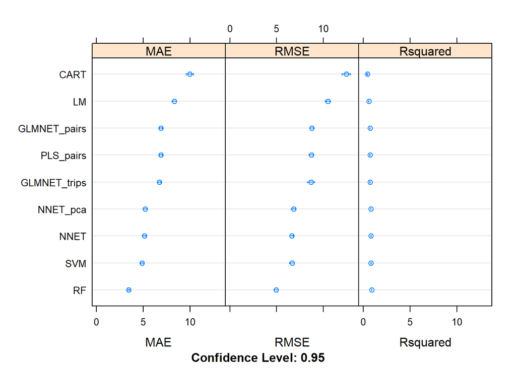

```r
dotplot(my_results)
```

Or we can manually extract the results to make a custom figure with `ggplot2`. Which model seems to be the best?

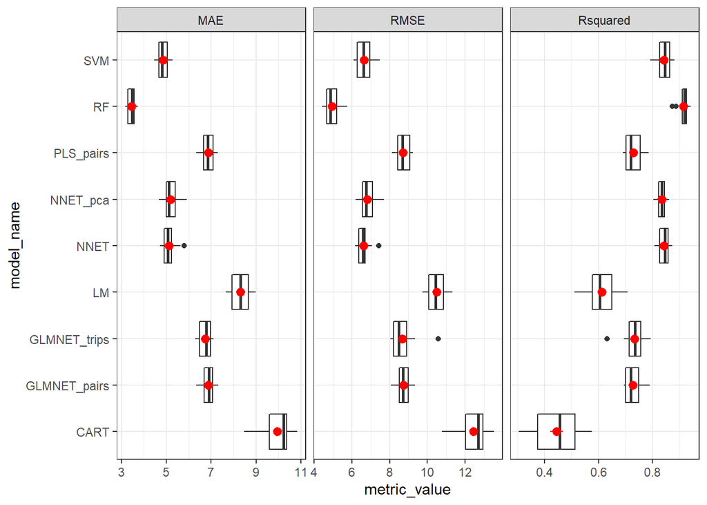

```r
resamples_lf <- as.data.frame(my_results, metric = "RMSE") %>% tbl_df() %>%
  mutate(metric_name = "RMSE") %>%
  bind_rows(as.data.frame(my_results, metric = "Rsquared") %>% tbl_df() %>%
              mutate(metric_name = "Rsquared")) %>%
  bind_rows(as.data.frame(my_results, metric = "MAE") %>% tbl_df() %>%
              mutate(metric_name = "MAE")) %>%
  tidyr::gather(key = "model_name", value = "metric_value",
                -Resample, -metric_name)

resamples_lf %>%
  ggplot(mapping = aes(x = model_name, y = metric_value)) +
  geom_boxplot() +
  stat_summary(fun.data = "mean_se",
               color = "red",
               fun.args = list(mult = 1)) +
  coord_flip() +
  facet_grid(. ~ metric_name, scales = "free_x") +
  theme_bw()
```

In addition to comparing performance across models, we can consider the correlation between models. Let’s focus on the RMSE metric and examine a scatter plot matrix across all folds and repeats.

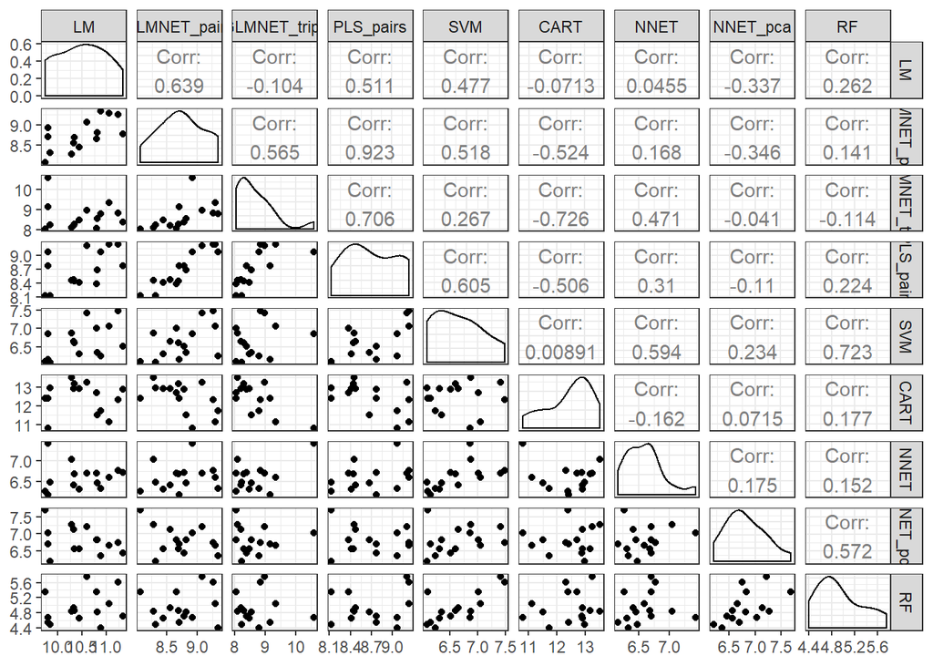

```r
as.data.frame(my_results, metric = "RMSE") %>%
  GGally::ggpairs(columns = 1:9) +
  theme_bw()
```

## Hold-out set predictions

By default, `caret` does not store all of the cross-validation fold hold-out set predictions in order to save memory. Let’s retrain the random forest model and the elastic net with all pair-wise interactions, but this time force all hold-out set predictions to be saved. To do so, the `trainControl()` function is modified, as shown below.

```r
my_ctrl_pred <- trainControl(method = "repeatedcv", number = 5, repeats = 3,
                             savePredictions = TRUE)
```

Now retrain the random forest and elastic net models.

```r
set.seed(20201)
fit_rf_pred <- train(strength ~ ., data = my_concrete,
                     method = "rf",
                     metric = my_metric,
                     preProc = c("center", "scale"),
                     trControl = my_ctrl_pred)
```

```r
set.seed(20201)
fit_glmnet_pairs_pred <- train(strength ~ (.)^2, data = my_concrete,
                               method = "glmnet",
                               metric = my_metric,
                               preProc = c("center", "scale"),
                               trControl = my_ctrl_pred)
```

Let’s now visualize the random forest hold-out set predictions compared to the observations in a predicted vs observed style figure. The figure below breaks up each fold within each repeat. Visually, how do you think the model performed?

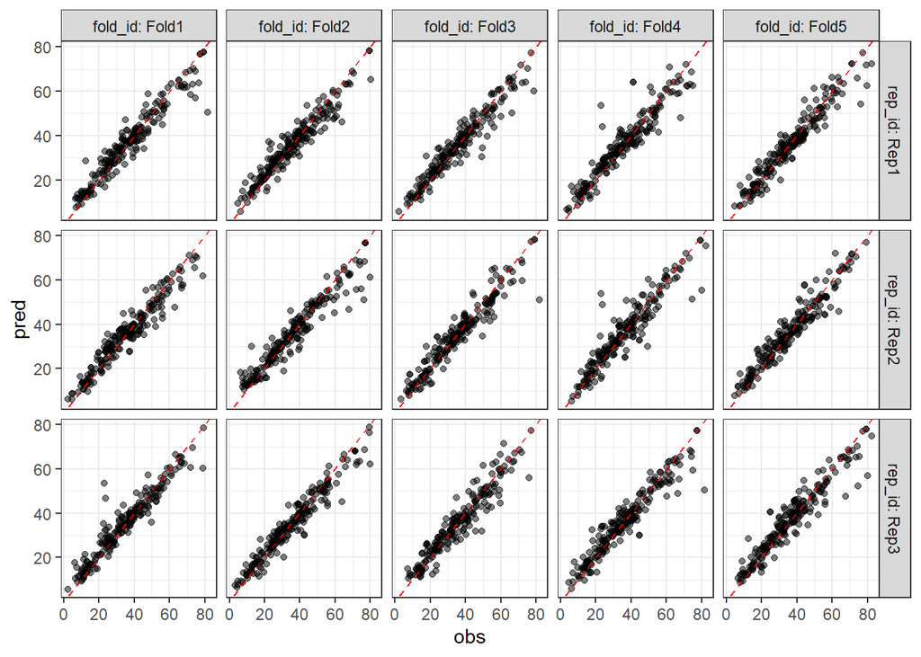

```r
fit_rf_pred$pred %>% tbl_df() %>%
  filter(mtry == fit_rf_pred$bestTune$mtry) %>%
  tidyr::separate(Resample,
                  c("fold_id", "rep_id"),
                  sep = "\\.",
                  remove = FALSE) %>%
  ggplot(mapping = aes(x = obs, y = pred)) +
  geom_point(alpha = 0.5) +
  geom_abline(slope = 1, intercept = 0,
              color = "red", linetype = "dashed") +
  facet_grid(rep_id ~ fold_id, labeller = "label_both") +
  theme_bw()
```

Constrast the random forest performance with the elastic net performance.

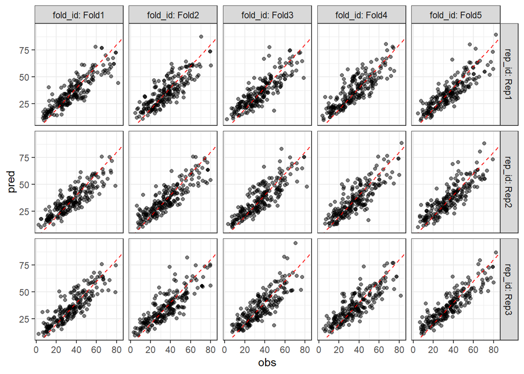

```r
fit_glmnet_pairs_pred$pred %>% tbl_df() %>%
  filter(alpha == fit_glmnet_pairs_pred$bestTune$alpha,
         lambda == fit_glmnet_pairs_pred$bestTune$lambda) %>%
  tidyr::separate(Resample,
                  c("fold_id", "rep_id"),
                  sep = "\\.",
                  remove = FALSE) %>%
  ggplot(mapping = aes(x = obs, y = pred)) +
  geom_point(alpha = 0.5) +
  geom_abline(slope = 1, intercept = 0,
              color = "red", linetype = "dashed") +
  facet_grid(rep_id ~ fold_id, labeller = "label_both") +
  theme_bw()
```

## Variable importance rankings

Complex non-linear models can be difficult to interpret. After all, they do not consist of simple coefficients that we can compare relative to zero. However, some complex models have methods that can rank the inputs. We will discuss how the random forest model is capable of doing so later in the semester. The variable importance ranking is graphically shown below.

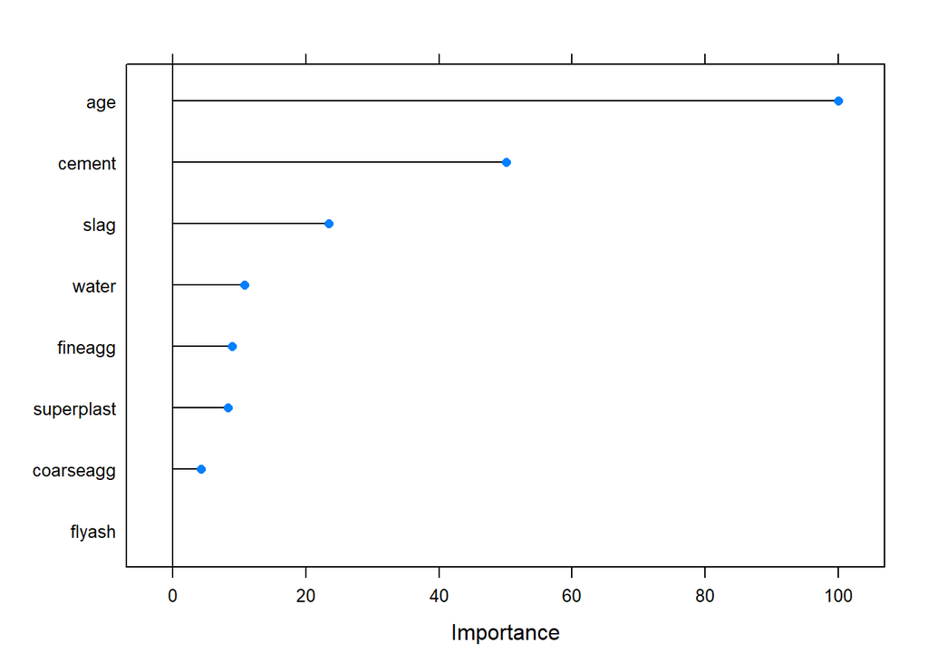

```r
plot(varImp(fit_rf))
```